# Exploring Countermovement Jump (CMJ) Scan Movement Signatures in Men’s Collegiate Lacrosse Athletes

Bernadette D’Alonzo

### Overview

Members of Penn Athletics, Penn Sports Medicine, and the Penn Injury Science Center have been collaborating on a large study titled, “Force Plate Analysis in Collegiate Athletes: An Epidemiologic and Injury Prevention Study,” to evaluate a program that has been active at Penn over the last 5 years. The overarching goal of that study is to investigate whether force plate measurements can predict injuries, and performance outcomes, and whether (and how) measurements vary across sports and sex. Exploring this may help to identify sport-specific profiles that may inform customized strength and conditioning injury prevention programs. The objective of this class project is to take a step back from prediction to first answer the question of whether and how these measurements vary between athletes from the same sport compared to within one athlete over time, and I examine this in the context of men’s varsity lacrosse players. For this project, I worked with a large interdisciplinary team including: Dr. Doug Wiebe, Professor of Epidemiology and Director of the Penn Injury Science Center (PISC), Dr. Abby Bretzin, Postdoctoral Fellow at PISC, Dr. Jeremy Weeks, Associate Director of Penn Strength & Conditioning (and Director of Research), and Dr. Brian Sennett, Chair of Athletic Medicine at Penn.

### Introduction

The specific problem that this project addresses, is that the field currently does not have a strong understanding of how and the extent to which force plate measurements vary across collegiate athletes in the larger study playing the same sport, and within an athlete over time. This is a key concept to explore prior to estimating or predicting injury. Penn Athletics in particular is interested in this issue, having used force plates for 5 years, yet lacking evidence of the utility of what they are measuring. Ultimately, by identifying individuals who may be at increased risk of injury, we may be able to inform the development of targeted injury prevention programs, thereby improving countermeasure effectiveness. Sparta Science is a sports performance and injury evaluation tool utilized by multiple human movement-based industries, with significant use in military, athletic, and clinical settings. Sparta Science has been described as having a technology that may enable identifying athletes at-risk for sustaining an injury. To lay the groundwork for next studies on injury prediction, this project investigates some of the metrics that force plates measure.

The collaborative nature of the team involved in this study is a strength and it’s critical to the success of any of our projects. Penn’s Strength & Conditioning leadership and staff bring expertise in research utilizing force plates to date and Penn’s utilization and implementation of Sparta Science assessments. Penn Sports Medicine and Athletic Training contribute knowledge regarding the appropriateness and application of findings related to injury. Finally, Epidemiologists and Data Scientists provide support for study design, identify opportunities for natural and planned experiments, and interpretation of results.

From meetings with Strength & Conditioning, we have learned that the technology used in the Sparta Science system consists of a force plate, proprietary software, and a dataset projected to consist of data captured from more than 1,500,000 assessments. Current Sparta Science set-up at Penn consists of force plates with dedicated computers and software, and it is used with athletes across all years and varsity sports. Athletes begin with a standardized warm up that is completed just prior to the assessments; counter movement jump (CMJ); single leg balance scan, and single arm plank scan. The results of each assessment are computed by the software and converted to T-scores, by comparing to the Sparta Science dataset. For the CMJ assessment, the system generates industry-standard variables of force/time including Load, Explode, and Drive, which we will examine in this project. These scores represent an individual’s ability to Create, Transfer, and Apply force efficiently and are referred to by Sparta as the individual’s Movement Signature™. We have also learned that men’s lacrosse coaches have utilized the software most consistently in recent years, and at the encouragement of the Epidemiologists providing guidance on this project, I focus on those athletes here. From Sports Medicine and Athletic Training, we have learned that lower-extremity injuries (LEIs) have been common among men’s lacrosse players at Penn, further underscoring this population as an ideal one to first explore patterns in CMJ scan measurements among team members and over time.

### Methods

The data utilized in this analysis were extracted from the Sparta Science platform and are part of a larger project, as discussed above. The main goal of this class project was to use descriptive analyses and data visualization to explore and present the data in a meaningful way, and to aid in hypothesis generation.

To begin, I loaded the appropriate tidyverse packages and read in the Sparta Science scan data file (containing all sports). I used the package gtsummary to create the summary tables below.

```r
library(dplyr)
library(ggplot2)
library(gtsummary)
```

```r
sparta.scans <- read.csv("U:/PhD program/600 Data Science_Final proj_Sparta/sparta_scan_summaries.csv", header = TRUE)
```

```r
#ID sport with most number of scans - we see that it's Men's Lacrosse.
scans.by.sport <- sparta.scans %>%
  group_by(Group.s.) %>%
  summarise(n()) %>%
  arrange(desc(`n()`))

sparta.scans %>%
  select(Group.s.) %>%
  tbl_summary(
    sort = list(everything() ~ "frequency"),
    label = Group.s. ~ "Penn sport team and other") %>%
  modify_header(label ~ "Total Number of Scans") %>%
  bold_labels()
```

| Total Number of Scans | **N = 21,143**<sup>1</sup> |
| --- | --- |
| Penn sport team and other |  |
|  | 11,757 (56%) |
| Lacrosse (M) | 958 (4.5%) |
| Lacrosse (W) | 867 (4.1%) |
| Football | 811 (3.8%) |
| Rowing (W) | 553 (2.6%) |
| Baseball | 515 (2.4%) |
| Wrestling | 458 (2.2%) |
| Soccer (M) | 381 (1.8%) |
| Basketball (M) | 377 (1.8%) |
| Volleyball | 342 (1.6%) |
| Field Hockey | 328 (1.6%) |
| Basketball (W) | 309 (1.5%) |
| Lightweight Crew | 304 (1.4%) |
| Soccer (W) | 292 (1.4%) |
| Track and Field (M) | 276 (1.3%) |
| Track and Field (W) | 249 (1.2%) |
| Heavyweight Crew | 244 (1.2%) |
| Softball | 238 (1.1%) |
| Sprint Football | 236 (1.1%) |
| Swimming (W) | 202 (1.0%) |
| Squash (W) | 168 (0.8%) |
| Squash (M) | 164 (0.8%) |
| Swimming (M) | 164 (0.8%) |
| Tennis (M) | 135 (0.6%) |
| Gymnastics | 132 (0.6%) |
| Tennis (W) | 130 (0.6%) |
| Golf (M) | 112 (0.5%) |
| Cheerleading | 103 (0.5%) |
| Staff | 101 (0.5%) |
| Fencing (W) | 76 (0.4%) |
| Golf (W) | 70 (0.3%) |
| Fencing (M) | 57 (0.3%) |
| Field Hockey; Lacrosse (W) | 26 (0.1%) |
| Heavyweight Crew; Lightweight Crew | 8 (<0.1%) |

<sup>*1*</sup> Statistics presented: n (%)

Next, I cleaned the dataset, removing identifiers. I restricted the sample to Men’s Lacrosse and to Counter Movement Jump (CMJ) scan only. I assigned a new unique ID to each athlete (id.new):

```r
#Cleaning up dataset here - removing identifiers, new labels, Men's Lax only, Jump scan only.
sparta.scans.clean <- sparta.scans %>%
  select(Unique.ID, Group.s., Date, Time, Scan.Type, Load.t.score, Explode.t.score, Drive.t.score, Jump.height..in., Weight..lb., Injury.risk) %>%
  rename(id = Unique.ID, sport = Group.s., date.scan = Date, time.scan = Time, scan.type = Scan.Type, load.tscore = Load.t.score, explode.tscore = Explode.t.score, drive.tscore = Drive.t.score, jump.ht.in = Jump.height..in., jump.wt.lb = Weight..lb., injury.riskscore = Injury.risk) %>%
  filter(sport == "Lacrosse (M)") %>%
  filter(scan.type == "Jump")

#Check if missing - none.
#sapply(sparta.scans.clean, function(x) length(x[is.na(x)]))

#Assigning new unique ID (pre-assigned from software is very long).
sparta.scans.clean <- sparta.scans.clean %>%
  group_by(id) %>%
  mutate(id.new = row_number())
#Removing old ID
sparta.scans.clean <- sparta.scans.clean[-c(1)]

#More cleaning - make new ID class character.
sparta.scans.clean$id.new <- as.character(sparta.scans.clean$id.new)
#Creating new variable, id.new as a factor
sparta.scans.clean <- sparta.scans.clean %>%
  mutate(id.new_factor = factor(id.new, levels = unique(id.new)))
#Remove old ID from software.
sparta.scans.clean <- sparta.scans.clean[-c(1)]
#Make injury risk score a factor (1-5) from numeric.
sparta.scans.clean$injury.riskscore <- as.factor(sparta.scans.clean$injury.riskscore)
```

The final dataset here:

```r
#Cleaned dataset here.
str(sparta.scans.clean)
```

```
## tibble [852 x 11] (S3: tbl_df/tbl/data.frame)
##  $ date.scan       : chr [1:852] "2020-02-20" "2020-02-20" "2020-02-20" "2020-02-20" ...
##  $ time.scan       : chr [1:852] "18:56:03" "18:54:00" "18:52:02" "18:49:54" ...
##  $ scan.type       : chr [1:852] "Jump" "Jump" "Jump" "Jump" ...
##  $ load.tscore     : num [1:852] 57.9 36.2 48.7 42.7 49 ...
##  $ explode.tscore  : num [1:852] 50.8 33.9 58.4 46.7 39.1 ...
##  $ drive.tscore    : num [1:852] 39.8 65.1 42.4 46.3 72.4 ...
##  $ jump.ht.in      : num [1:852] 16 15.3 18.8 16.3 19.4 ...
##  $ jump.wt.lb      : num [1:852] 186 165 167 176 186 ...
##  $ injury.riskscore: Factor w/ 5 levels "0","1","2","3",..: 2 4 2 2 4 2 2 4 4 2 ...
##  $ id.new          : chr [1:852] "1" "1" "1" "1" ...
##  $ id.new_factor   : Factor w/ 35 levels "1","2","3","4",..: 1 1 1 1 1 1 1 1 1 1 ...
```

### Results

I looked at 35 Men’s lacrosse players with 852 jump scans from 2016-2020 (athletes with complete data).

```r
#Men's lacrosse - we have 35 players, 852 jump scans
#length(unique(sparta.scans.clean$id.new))

#This table shows the number of scans per athlete, range 49-1
scans.per.athlete <- sparta.scans.clean %>%
  group_by(id.new) %>%
  summarise(n()) %>%
  arrange(desc(`n()`))

sparta.scans.clean %>%
  select(id.new) %>%
  tbl_summary(
    sort = list(everything() ~ "frequency"),
    label = id.new ~ "ID") %>%
  modify_header(label ~ "Number of Scans per Athlete") %>%
  bold_labels()
```

| Number of Scans per Athlete | **N = 852**<sup>1</sup> |
| --- | --- |
| ID |  |
| 1 | 49 (5.8%) |
| 2 | 49 (5.8%) |
| 3 | 49 (5.8%) |
| 4 | 49 (5.8%) |
| 5 | 49 (5.8%) |
| 6 | 47 (5.5%) |
| 7 | 46 (5.4%) |
| 8 | 42 (4.9%) |
| 9 | 33 (3.9%) |
| 10 | 31 (3.6%) |
| 11 | 30 (3.5%) |
| 12 | 30 (3.5%) |
| 13 | 29 (3.4%) |
| 14 | 28 (3.3%) |
| 15 | 26 (3.1%) |
| 16 | 25 (2.9%) |
| 17 | 24 (2.8%) |
| 18 | 21 (2.5%) |
| 19 | 19 (2.2%) |
| 20 | 19 (2.2%) |
| 21 | 19 (2.2%) |
| 22 | 19 (2.2%) |
| 23 | 17 (2.0%) |
| 24 | 17 (2.0%) |
| 25 | 15 (1.8%) |
| 26 | 13 (1.5%) |
| 27 | 11 (1.3%) |
| 28 | 10 (1.2%) |
| 29 | 10 (1.2%) |
| 30 | 7 (0.8%) |
| 31 | 5 (0.6%) |
| 32 | 5 (0.6%) |
| 33 | 4 (0.5%) |
| 34 | 4 (0.5%) |
| 35 | 1 (0.1%) |

<sup>*1*</sup> Statistics presented: n (%)

I explored “Injury Risk Score” first, which ranges from 0-low to 5-high risk of injury. We see that for the majority of scans (47%; almost half) Injury Risk Score was reported to be 1, followed by 3, then 0.

```r
#Shows frequencies of scans by injury risk score (scale range 0-5, no 4)
scans.injury.riskscore <- sparta.scans.clean %>% count(injury.riskscore)
#print(scans.injury.riskscore)

sparta.scans.clean %>%
  select(injury.riskscore) %>%
  tbl_summary(label = injury.riskscore ~ "(0-5)") %>%
  modify_header(label ~ "Injury Risk Score")
```

| Injury Risk Score | **N = 852**<sup>1</sup> |
| --- | --- |
| (0-5) |  |
| 0 | 201 (24%) |
| 1 | 397 (47%) |
| 2 | 20 (2.3%) |
| 3 | 225 (26%) |
| 5 | 9 (1.1%) |

<sup>*1*</sup> Statistics presented: n (%)

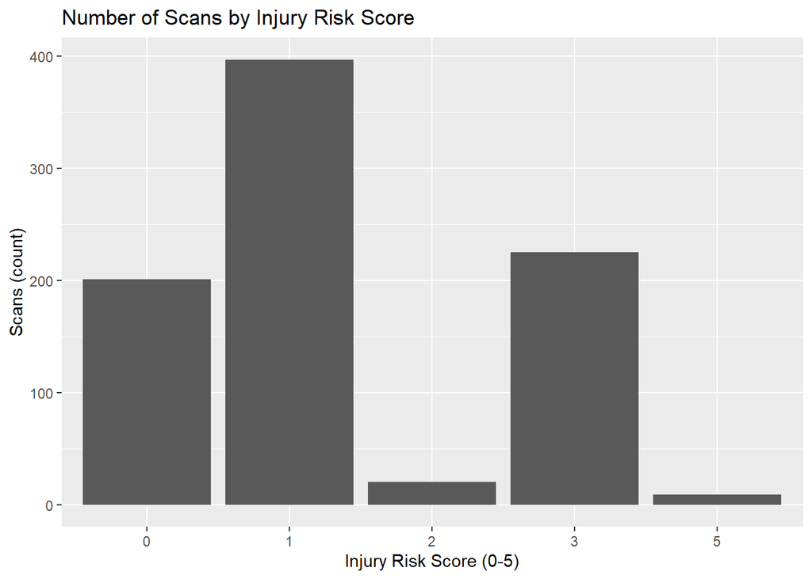

```r
#This shows that the most common injury risk score is 1 (then 3, 0, 2, 5)
ggplot(data = sparta.scans.clean, aes(x = injury.riskscore)) +
  geom_bar() +
  labs(y = "Scans (count)",
     x = "Injury Risk Score (0-5)") +
  ggtitle("Number of Scans by Injury Risk Score")
```

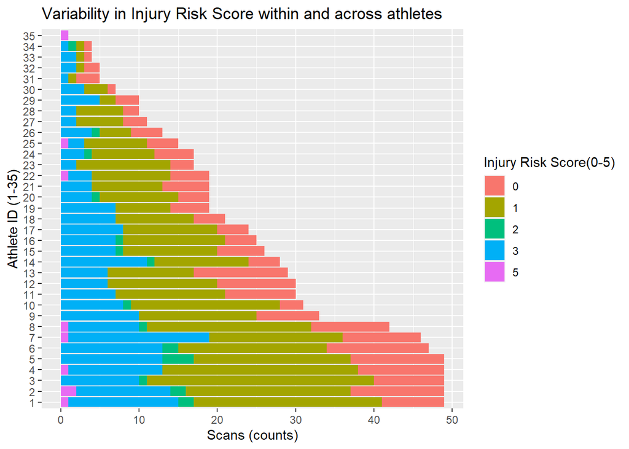

```r
#This shows the variability in scans by injury risk score both within the same athlete and across the 35 M lacrosse athletes.
ggplot(data = sparta.scans.clean, aes(y = id.new_factor, fill = injury.riskscore)) +
  geom_bar() +
  labs(y = "Athlete ID (1-35)",
     x = "Scans (counts)",
     fill = "Injury Risk Score(0-5)") +
  ggtitle("Variability in Injury Risk Score within and across athletes")
```

To explore another facet of the Counter Movement Jump (CMJ), I looked at Injury Risk Score and Jump Height below. We see that in general, higher jumps seem to coincide with lower Injury Risk Scores; 0 and 2. We may have expected to see some sort of dose response relationship, however, Jump Height seems to be fairly consistent across all Injury Risk Scores.

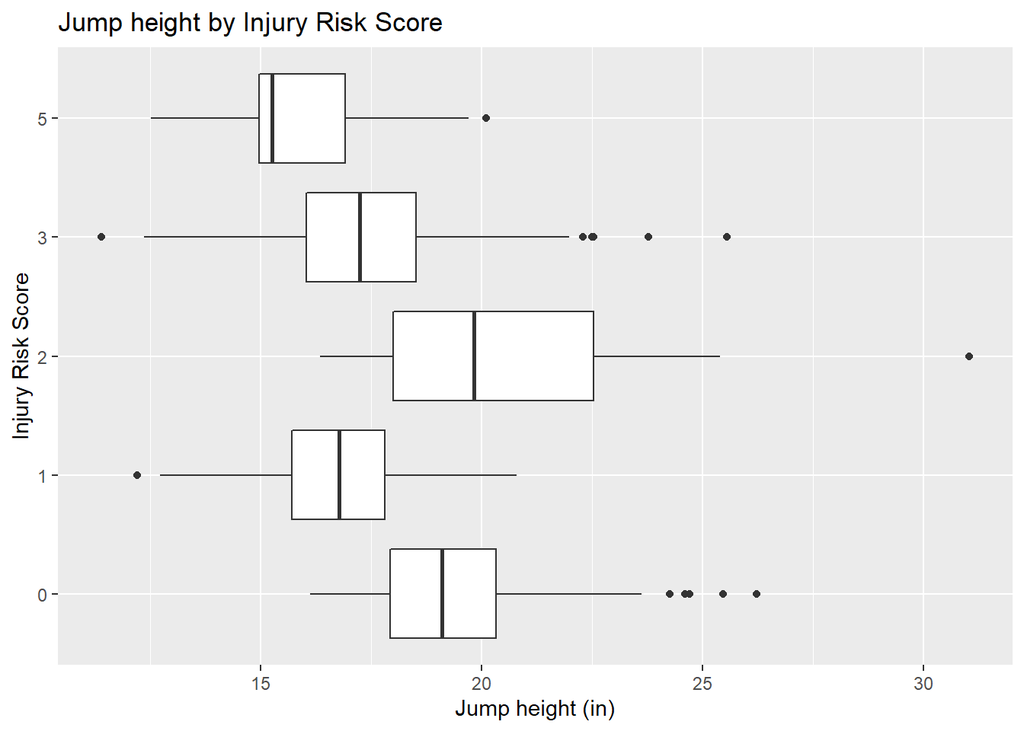

```r
#Jump height and injury risk score
#ggplot(data = sparta.scans.clean, aes(x = jump.ht.in, y = injury.riskscore)) +
  #geom_point()
ggplot(data = sparta.scans.clean, aes(x = jump.ht.in, y = injury.riskscore)) +
  geom_boxplot() +
  labs(y = "Injury Risk Score",
        x = "Jump height (in)") +
  ggtitle("Jump height by Injury Risk Score")
```

After Injury Risk Score, I explored the 3 variables that make up the Sparta Movement Signature; LOAD, EXPLODE, and DRIVE (expressed as tscores). Looking across all 35 athletes, we see that most athletes’ median scores in all 3 measures center around 50, however, we see consistent variability within a given athlete’s scores. This is additional motivation for future studies to determine what factors may be contributing to a change in score over time.

```r
library(gridExtra)
```

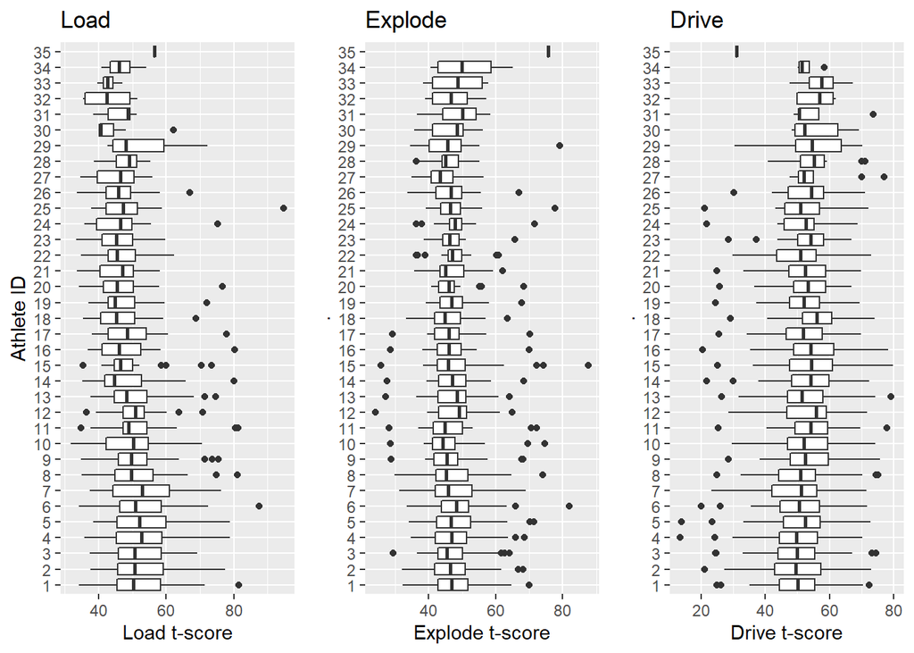

```r
#This shows median, IQR of LOAD, EXPLODE, DRIVE tscores within and across all M lacrosse athletes
#LOAD
#ggplot(data = sparta.scans.clean, aes(x = load.tscore, y = id.new)) +
  #geom_point()
box.loadt <- ggplot(data = sparta.scans.clean, aes(x = load.tscore, y = id.new_factor)) +
  geom_boxplot() +
  labs(y = "Athlete ID",
         x = "Load t-score") +
  ggtitle("Load")

#EXPLODE
#ggplot(data = sparta.scans.clean, aes(x = explode.tscore, y = id.new)) +
  #geom_point()
box.explodet <- ggplot(data = sparta.scans.clean, aes(x = explode.tscore, y = id.new_factor)) +
  geom_boxplot() +
  labs(y = ".",
       x = "Explode t-score") +
  ggtitle("Explode")

#DRIVE
#ggplot(data = sparta.scans.clean, aes(x = drive.tscore, y = id.new)) +
  #geom_point()
box.drivet <- ggplot(data = sparta.scans.clean, aes(x = drive.tscore, y = id.new_factor)) +
  geom_boxplot() +
  labs(y = ".",
       x = "Drive t-score") +
  ggtitle("Drive")

grid.arrange(box.loadt, box.explodet, box.drivet, ncol = 3)
```

I then examined the relationship between LOAD, EXPLODE, DRIVE scores and Injury Risk Score. We see below that low Injury Risk Score (0,1) seems to coincide with tscores primarily between 45-60, while higher Injury Risk Scores are clustered at tscores below 45 and above 60, resembling a U-shape relationship.[Please note: the grid.arrange function is useful, but as I worked on the 3 panels below, it was challenging to find a place to put the legend that didn’t compress the length/width of the graphs. I will continue to look for ways to update more in the future.]

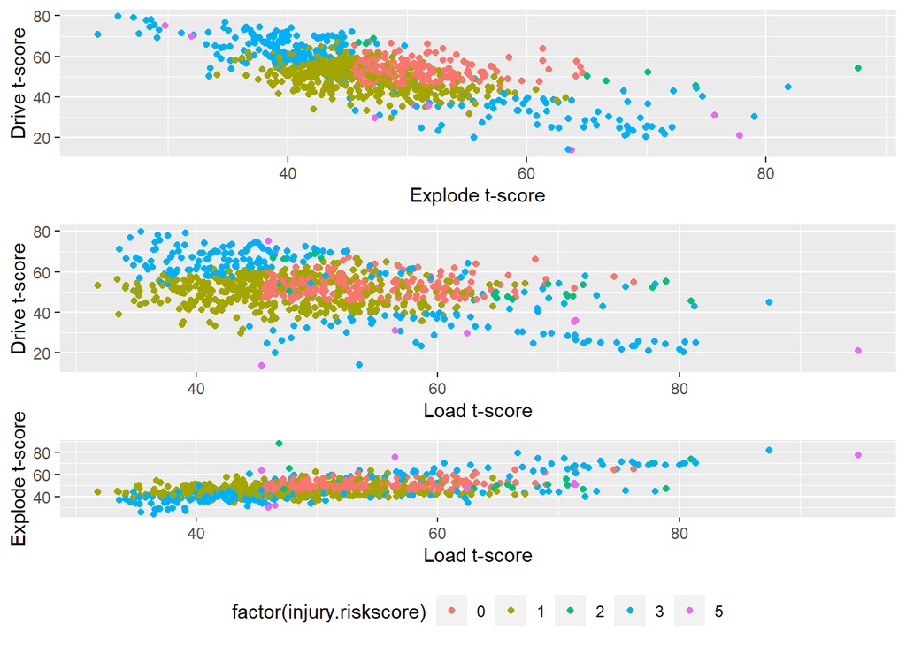

```r
#Scatterplots - LOAD, EXPLODE, DRIVE and injury.riskscore

scatter.explode.drivet <- ggplot(sparta.scans.clean, aes(x = explode.tscore, y = drive.tscore,)) +
  geom_point(aes(color=factor(injury.riskscore)), show.legend = FALSE) +
  labs(y = "Drive t-score",
         x = "Explode t-score")


scatter.load.drivet <- ggplot(sparta.scans.clean, aes(x = load.tscore, y = drive.tscore,)) +
  geom_point(aes(color=factor(injury.riskscore)), show.legend = FALSE) +
  labs(y = "Drive t-score",
        x = "Load t-score")

scatter.load.explodet <- ggplot(sparta.scans.clean, aes(x = load.tscore, y = explode.tscore,)) +
  geom_point(aes(color=factor(injury.riskscore))) +
  labs(y = "Explode t-score",
        x = "Load t-score") +
  theme(legend.position = "bottom")

grid.arrange(scatter.explode.drivet, scatter.load.drivet, scatter.load.explodet, nrow = 3)
```

Despite being 3 distinct measures, as discussed above, LOAD, EXPLODE, DRIVE can really be thought of together as one overall summary measure. So, in order to better conceptualize LOAD, EXPLODE, and DRIVE scores as one measure, I generated a variable similar to Sparta Science’s Movement Signature. I split each variable LOAD, EXPLODE, and DRIVE into tertiles and classified each scan according to “High,” “Medium,” “Low” on each measure. I then concatenated them, creating a “Jump Profile” for each jump scan.

```r
#Splitting LOAD, EXPLODE, DRIVE tscores into tertiles - low, med, high and added these columns to df
sparta.scans.clean <- sparta.scans.clean %>%
  mutate(load.tert = ntile(load.tscore, 3)) %>%
  mutate(load.tert = if_else(load.tert == 1, 'Low', if_else(load.tert == 2, 'Medium', 'High'))) %>%
  mutate(explode.tert = ntile(explode.tscore, 3)) %>%
  mutate(explode.tert = if_else(explode.tert == 1, 'Low', if_else(explode.tert == 2, 'Medium', 'High'))) %>%
  mutate(drive.tert = ntile(drive.tscore, 3)) %>%
  mutate(drive.tert = if_else(drive.tert == 1, 'Low', if_else(drive.tert == 2, 'Medium', 'High'))) %>%
  arrange(id.new)
#concatenate their "movement signature" into a "jump profile"
sparta.scans.clean$jump.profile <- paste(sparta.scans.clean$load.tert,sparta.scans.clean$explode.tert,sparta.scans.clean$drive.tert)

head(sparta.scans.clean)
```

```
## # A tibble: 6 x 15
##   date.scan  time.scan scan.type load.tscore explode.tscore drive.tscore jump.ht.in jump.wt.lb injury.riskscore id.new id.new_factor load.tert explode.tert drive.tert jump.profile
##   <chr>      <chr>     <chr>           <dbl>          <dbl>        <dbl>      <dbl>      <dbl> <fct>            <chr>  <fct>         <chr>     <chr>        <chr>      <chr>
## 1 2020-02-20 18:56:03  Jump             57.9           50.8         39.8       16.0       186. 1                1      1             High      High         Low        High High Low
## 2 2020-02-20 18:54:00  Jump             36.2           33.9         65.1       15.3       165. 3                1      1             Low       Low          High       Low Low High
## 3 2020-02-20 18:52:02  Jump             48.7           58.4         42.4       18.8       167. 1                1      1             Medium    High         Low        Medium High Low
## 4 2020-02-20 18:49:54  Jump             42.7           46.7         46.3       16.3       176. 1                1      1             Low       Medium       Low        Low Medium Low
## 5 2020-02-20 18:46:55  Jump             49.0           39.1         72.4       19.4       186. 3                1      1             Medium    Low          High       Medium Low High
## 6 2020-02-20 18:43:35  Jump             61.0           42.7         55.1       17.0       206. 1                1      1             High      Low          Medium     High Low Medium
```

```r
#This shows variability in LOAD, EXPLODE, DRIVE within and across athletes
#Load
bar.loadprofile <- ggplot(data = sparta.scans.clean, aes(y = id.new_factor, fill = load.tert)) +
  geom_bar(show.legend = FALSE) +
  labs(y = "Athlete ID",
       x = "Scans (count)",
       fill = "Load tertiles") +
  ggtitle("Load")

#Explode
bar.explodeprofile <- ggplot(data = sparta.scans.clean, aes(y = id.new_factor, fill = explode.tert)) +
  geom_bar() +
  labs(y = ".",
       x = "Scans (count)",
       fill = "Tertiles") +
  ggtitle("Explode") +
  theme(legend.position = "bottom")

#Drive
bar.driveprofile <- ggplot(data = sparta.scans.clean, aes(y = id.new_factor, fill = drive.tert)) +
  geom_bar(show.legend = FALSE) +
  labs(y = ".",
       x = "Scans (count)",
       fill = "Drive tertiles") +
  ggtitle("Drive")
```

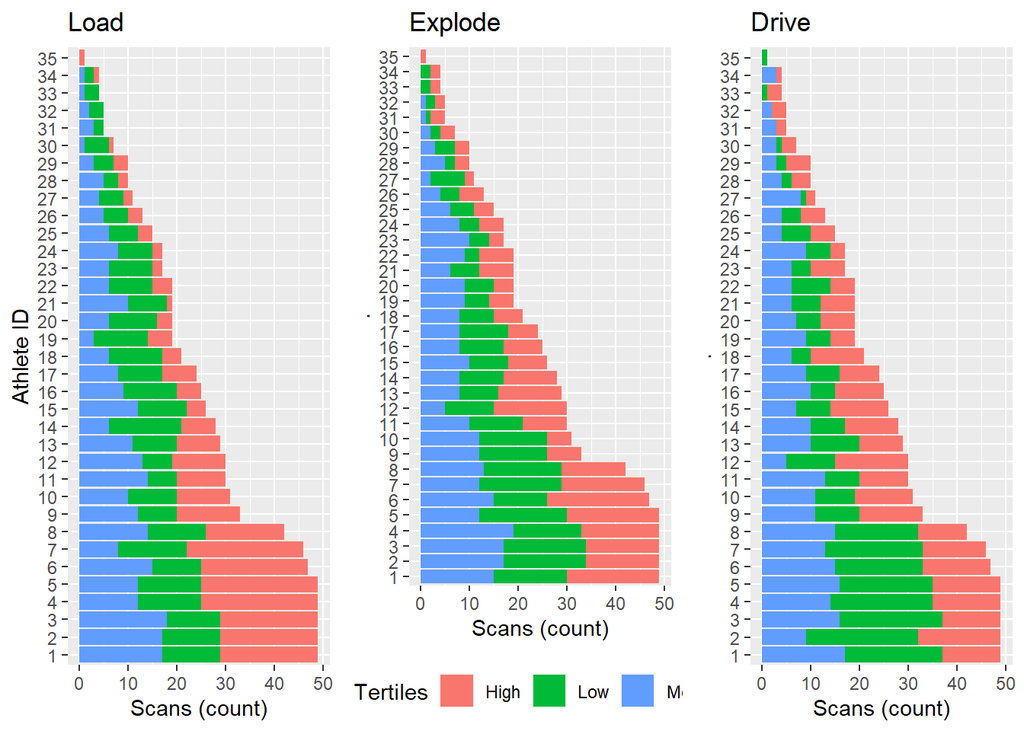

```r
grid.arrange(bar.loadprofile, bar.explodeprofile, bar.driveprofile, ncol = 3)
```

Putting these pieces together, I then looked at jump profile within an athlete and across our 35 Men’s Lacrosse players, and saw a lot of variability here as well.

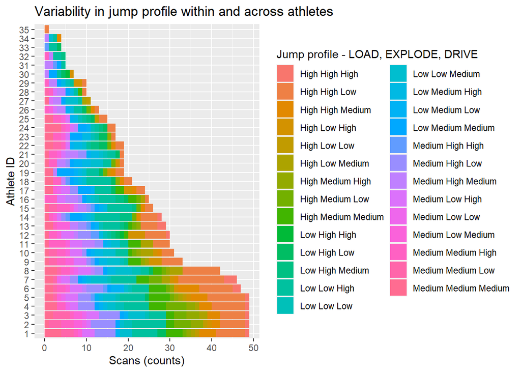

```r
#This shows the variability in jump profile within and across athletes
ggplot(data = sparta.scans.clean, aes(y = id.new_factor, fill = jump.profile)) +
  geom_bar() +
  labs(y = "Athlete ID",
       x = "Scans (counts)",
       fill = "Jump profile - LOAD, EXPLODE, DRIVE") +
  ggtitle("Variability in jump profile within and across athletes")
```

Finally, I was interested in examining how these LOAD, EXPLODE, DRIVE variables were associated with Injury Risk Score as an outcome variable. Below, I plot each measure by Injury Risk Score. Here, we expected to see some type of dose response relationship between all or some of the measures and Injury Risk Score. We do not see this.

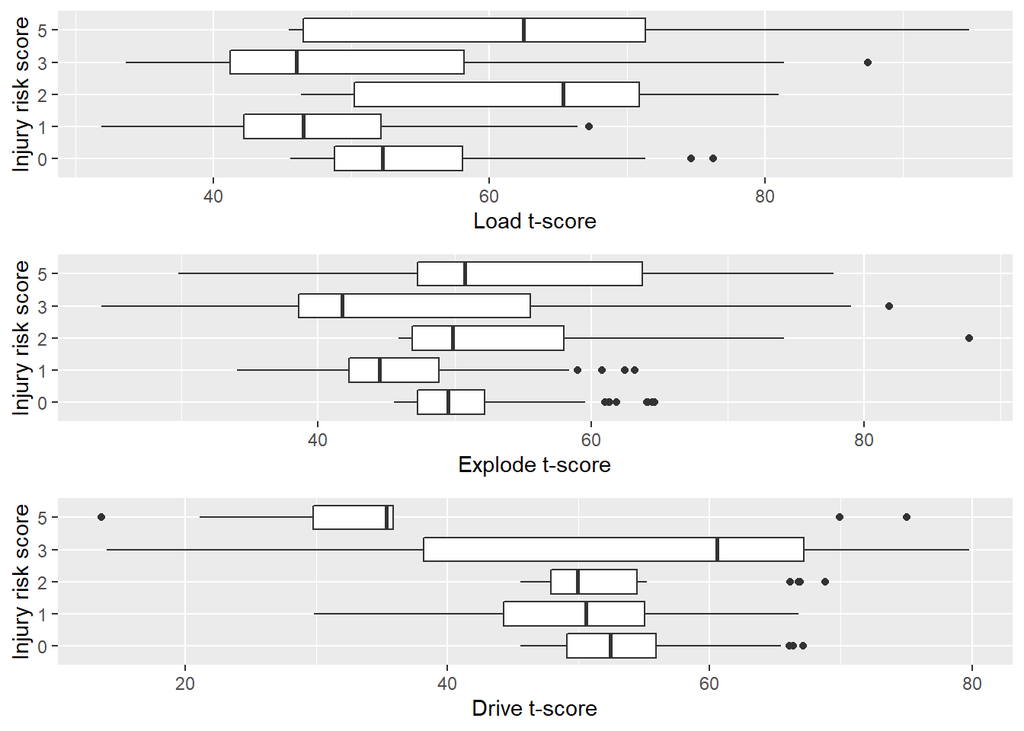

```r
boxplot.load.injury <- ggplot(sparta.scans.clean, aes(x = load.tscore, y = injury.riskscore)) +
  geom_boxplot() +
  labs(y = "Injury risk score",
        x = "Load t-score")

boxplot.explode.injury <- ggplot(sparta.scans.clean, aes(x = explode.tscore, y = injury.riskscore)) +
  geom_boxplot() +
  labs(y = "Injury risk score",
        x = "Explode t-score")

boxplot.drive.injury <- ggplot(sparta.scans.clean, aes(x = drive.tscore, y = injury.riskscore)) +
  geom_boxplot() +
  labs(y = "Injury risk score",
        x = "Drive t-score")

grid.arrange(boxplot.load.injury,boxplot.explode.injury,boxplot.drive.injury, nrow = 3)
```

As a first (somewhat preliminary) pass, I performed bivariate analysis, using linear(OLS) regression to look at the pairwise relationships between: 1) Load tscore -> Injury Risk Score 2) Explode tscore -> Injury Risk Score 3) Drive tscore -> Injury Risk Score

I then fit a multivariate linear regression model: 4) Load, Explode, Drive as predictors of Injury Risk Score

```r
sparta.scans.clean$injury.riskscore.cont <- as.numeric(sparta.scans.clean$injury.riskscore)

#Examining correlation between LOAD, EXPLODE, DRIVE and Injury Risk Score
cor(sparta.scans.clean$load.tscore, sparta.scans.clean$injury.riskscore.cont)
```

```
## [1] 0.01474969
```

```r
cor(sparta.scans.clean$explode.tscore, sparta.scans.clean$injury.riskscore.cont)
```

```
## [1] -0.09159215
```

```r
cor(sparta.scans.clean$drive.tscore, sparta.scans.clean$injury.riskscore.cont)
```

```
## [1] 0.05024299
```

```r
#Linear regression - bivariate
summary(lm(injury.riskscore.cont ~ load.tscore, data = sparta.scans.clean))
```

```
##
## Call:
## lm(formula = injury.riskscore.cont ~ load.tscore, data = sparta.scans.clean)
##
## Residuals:
##     Min      1Q  Median      3Q     Max
## -1.3930 -0.3666 -0.3385  1.6141  2.6612
##
## Coefficients:
##             Estimate Std. Error t value Pr(>|t|)
## (Intercept) 2.258965   0.209327   10.79   <2e-16 ***
## load.tscore 0.001758   0.004087    0.43    0.667
## ---
## Signif. codes:  0 '***' 0.001 '**' 0.01 '*' 0.05 '.' 0.1 ' ' 1
##
## Residual standard error: 1.137 on 850 degrees of freedom
## Multiple R-squared:  0.0002176,  Adjusted R-squared:  -0.0009587
## F-statistic: 0.185 on 1 and 850 DF,  p-value: 0.6673
```

```r
summary(lm(injury.riskscore.cont ~ explode.tscore, data = sparta.scans.clean))
```

```
##
## Call:
## lm(formula = injury.riskscore.cont ~ explode.tscore, data = sparta.scans.clean)
##
## Residuals:
##     Min      1Q  Median      3Q     Max
## -1.3699 -0.4573 -0.3755  1.4893  3.0450
##
## Coefficients:
##                 Estimate Std. Error t value Pr(>|t|)
## (Intercept)     2.957250   0.230697  12.819  < 2e-16 ***
## explode.tscore -0.012889   0.004806  -2.682  0.00747 **
## ---
## Signif. codes:  0 '***' 0.001 '**' 0.01 '*' 0.05 '.' 0.1 ' ' 1
##
## Residual standard error: 1.132 on 850 degrees of freedom
## Multiple R-squared:  0.008389,   Adjusted R-squared:  0.007223
## F-statistic: 7.191 on 1 and 850 DF,  p-value: 0.007469
```

```r
summary(lm(injury.riskscore.cont ~ drive.tscore, data = sparta.scans.clean))
```

```
##
## Call:
## lm(formula = injury.riskscore.cont ~ drive.tscore, data = sparta.scans.clean)
##
## Residuals:
##     Min      1Q  Median      3Q     Max
## -1.4308 -0.3984 -0.3347  1.5447  2.8588
##
## Coefficients:
##              Estimate Std. Error t value Pr(>|t|)
## (Intercept)  2.067720   0.194631  10.624   <2e-16 ***
## drive.tscore 0.005408   0.003687   1.467    0.143
## ---
## Signif. codes:  0 '***' 0.001 '**' 0.01 '*' 0.05 '.' 0.1 ' ' 1
##
## Residual standard error: 1.136 on 850 degrees of freedom
## Multiple R-squared:  0.002524,   Adjusted R-squared:  0.001351
## F-statistic: 2.151 on 1 and 850 DF,  p-value: 0.1428
```

```r
#Multivariate linear regression
injury.riskscore.cont.lm <- lm(injury.riskscore.cont ~ load.tscore + explode.tscore + drive.tscore, data = sparta.scans.clean)
summary(injury.riskscore.cont.lm)
```

```
##
## Call:
## lm(formula = injury.riskscore.cont ~ load.tscore + explode.tscore +
##     drive.tscore, data = sparta.scans.clean)
##
## Residuals:
##     Min      1Q  Median      3Q     Max
## -1.5139 -0.5872 -0.3317  1.4133  3.2023
##
## Coefficients:
##                 Estimate Std. Error t value Pr(>|t|)
## (Intercept)     2.920344   0.519156   5.625 2.52e-08 ***
## load.tscore     0.012750   0.005050   2.524  0.01177 *
## explode.tscore -0.023540   0.007317  -3.217  0.00134 **
## drive.tscore   -0.001948   0.004913  -0.396  0.69191
## ---
## Signif. codes:  0 '***' 0.001 '**' 0.01 '*' 0.05 '.' 0.1 ' ' 1
##
## Residual standard error: 1.129 on 848 degrees of freedom
## Multiple R-squared:  0.01599,    Adjusted R-squared:  0.01251
## F-statistic: 4.594 on 3 and 848 DF,  p-value: 0.003378
```

### References:

Load, Explode, and Drive. (Updated April 2020). Retrieved November 27, 2020, from https://success.spartascience.com/hc/en-us/articles/360044860713-Load-Explode-and-Drive

Sparta Science: About. (Updated 2020). Retrieved November 27, 2020 from https://spartascience.com/about